# Effects of Dredging Related Sedimentation on Larval Settlement in Harbor Porites Coral CODE

Sami

2024-05-01

```r
#Modify location as needed
data <- read.csv("./data.csv", header = TRUE)
```

# Data Cleaning

### Defining Data Frame

```r
#Look at data
head(data)
```

```
##   Trial Jar Treatment settle_n meta_n swim_n dead_n settle_prop meta_prop
## 1     1  1D         1        0      0      2      3         0.0       0.0
## 2     1  CD         0        4      0      1      0         0.8       0.0
## 3     1 10C        10        0      2      2      1         0.0       0.4
## 4     1 25D        25        2      2      1      0         0.4       0.4
## 5     1 50C        50        0      0      3      2         0.0       0.0
## 6     1 10D        10        0      1      4      0         0.0       0.2
##   swim_prop dead_prop
## 1       0.4       0.6
## 2       0.2       0.0
## 3       0.4       0.2
## 4       0.2       0.0
## 5       0.6       0.4
## 6       0.8       0.0
```

```r
#Change trial to a factor from an integer
data$Trial <- as.factor(data$Trial)
head(data)
```

```
##   Trial Jar Treatment settle_n meta_n swim_n dead_n settle_prop meta_prop
## 1     1  1D         1        0      0      2      3         0.0       0.0
## 2     1  CD         0        4      0      1      0         0.8       0.0
## 3     1 10C        10        0      2      2      1         0.0       0.4
## 4     1 25D        25        2      2      1      0         0.4       0.4
## 5     1 50C        50        0      0      3      2         0.0       0.0
## 6     1 10D        10        0      1      4      0         0.0       0.2
##   swim_prop dead_prop
## 1       0.4       0.6
## 2       0.2       0.0
## 3       0.4       0.2
## 4       0.2       0.0
## 5       0.6       0.4
## 6       0.8       0.0
```

```r
#Add a vector/column for natural log transformed concentration. Add a small value because of the presences of zeroes (controls) in the dataset.
data$logConc <- log(data$Treatment+0.0001)
head(data)
```

```
##   Trial Jar Treatment settle_n meta_n swim_n dead_n settle_prop meta_prop
## 1     1  1D         1        0      0      2      3         0.0       0.0
## 2     1  CD         0        4      0      1      0         0.8       0.0
## 3     1 10C        10        0      2      2      1         0.0       0.4
## 4     1 25D        25        2      2      1      0         0.4       0.4
## 5     1 50C        50        0      0      3      2         0.0       0.0
## 6     1 10D        10        0      1      4      0         0.0       0.2
##   swim_prop dead_prop      logConc
## 1       0.4       0.6  0.000099995
## 2       0.2       0.0 -9.210340372
## 3       0.4       0.2  2.302595093
## 4       0.2       0.0  3.218879825
## 5       0.6       0.4  3.912025005
## 6       0.8       0.0  2.302595093
```

```r
#Add column for total larvae
data$total_larvae <- data$settle_n + data$meta_n + data$swim_n +data$dead_n
head(data)
```

```
##   Trial Jar Treatment settle_n meta_n swim_n dead_n settle_prop meta_prop
## 1     1  1D         1        0      0      2      3         0.0       0.0
## 2     1  CD         0        4      0      1      0         0.8       0.0
## 3     1 10C        10        0      2      2      1         0.0       0.4
## 4     1 25D        25        2      2      1      0         0.4       0.4
## 5     1 50C        50        0      0      3      2         0.0       0.0
## 6     1 10D        10        0      1      4      0         0.0       0.2
##   swim_prop dead_prop      logConc total_larvae
## 1       0.4       0.6  0.000099995            5
## 2       0.2       0.0 -9.210340372            5
## 3       0.4       0.2  2.302595093            5
## 4       0.2       0.0  3.218879825            5
## 5       0.6       0.4  3.912025005            5
## 6       0.8       0.0  2.302595093            5
```

# Response: Settlement

### GLM Model Validation

```r
# Start with full, binomial model
mod1 <- glm(settle_prop ~ Treatment + Trial, family = binomial, weights = total_larvae,
            data = data)
summary(mod1)
```

```
##
## Call:
## glm(formula = settle_prop ~ Treatment + Trial, family = binomial,
##     data = data, weights = total_larvae)
##
## Coefficients:
##             Estimate Std. Error z value Pr(>|z|)
## (Intercept) -0.99333    0.30257  -3.283 0.001027 **
## Treatment   -0.05820    0.01509  -3.857 0.000115 ***
## Trial2      -0.97675    0.48887  -1.998 0.045720 *
## Trial3      -0.26293    0.43384  -0.606 0.544476
## Trial4       0.15186    0.43955   0.345 0.729720
## Trial5       0.46587    0.42240   1.103 0.270062
## ---
## Signif. codes:  0 '***' 0.001 '**' 0.01 '*' 0.05 '.' 0.1 ' ' 1
##
## (Dispersion parameter for binomial family taken to be 1)
##
##     Null deviance: 138.59  on 75  degrees of freedom
## Residual deviance: 101.93  on 70  degrees of freedom
## AIC: 181.85
##
## Number of Fisher Scoring iterations: 5
```

```r
# Extract residual deviance
residual_deviance <- deviance(mod1)

# Degrees of freedom
df <- nrow(model.matrix(mod1)) - length(coefficients(mod1))

# Compute p-value to test for overdispersion
p_value <- 1 - pchisq(residual_deviance, df)

# Print results
print(paste("Residual Deviance:", residual_deviance))
```

```
## [1] "Residual Deviance: 101.928725308631"
```

```r
print(paste("Degrees of freedom:", df))
```

```
## [1] "Degrees of freedom: 70"
```

```r
print(paste("P-value:", p_value))
```

```
## [1] "P-value: 0.0076322180057008"
```

Since there is evidence of overdispersion (p<0.05 in deviance goodness-of-fit test), let’s make this a quasibinomial model and compare the fit/performance of full or reduced models, and with or without log transformed concentration.

```r
mod2 <- glm(settle_prop ~ Treatment + Trial, family = quasibinomial, weights = total_larvae,
            data = data)
mod3 <- glm(settle_prop ~ logConc + Trial, family = quasibinomial, weights = total_larvae,
            data = data)
mod4 <- glm(settle_prop ~ Treatment, family = quasibinomial, weights = total_larvae,
            data = data)
mod5 <- glm(settle_prop ~ logConc, family = quasibinomial, weights = total_larvae,
            data = data)

# Compare full vs reduced models
anova(mod4, mod2, test = "Chisq")
```

```
## Analysis of Deviance Table
##
## Model 1: settle_prop ~ Treatment
## Model 2: settle_prop ~ Treatment + Trial
##   Resid. Df Resid. Dev Df Deviance Pr(>Chi)
## 1        74     111.98
## 2        70     101.93  4   10.054    0.187
```

```r
anova(mod5, mod3, test = "Chisq")
```

```
## Analysis of Deviance Table
##
## Model 1: settle_prop ~ logConc
## Model 2: settle_prop ~ logConc + Trial
##   Resid. Df Resid. Dev Df Deviance Pr(>Chi)
## 1        74     98.497
## 2        70     85.679  4   12.818  0.02479 *
## ---
## Signif. codes:  0 '***' 0.001 '**' 0.01 '*' 0.05 '.' 0.1 ' ' 1
```

Now let’s compare the model residuals for the two preferred models in the Chi-sq (anova) tests above: mod3 and mod4.

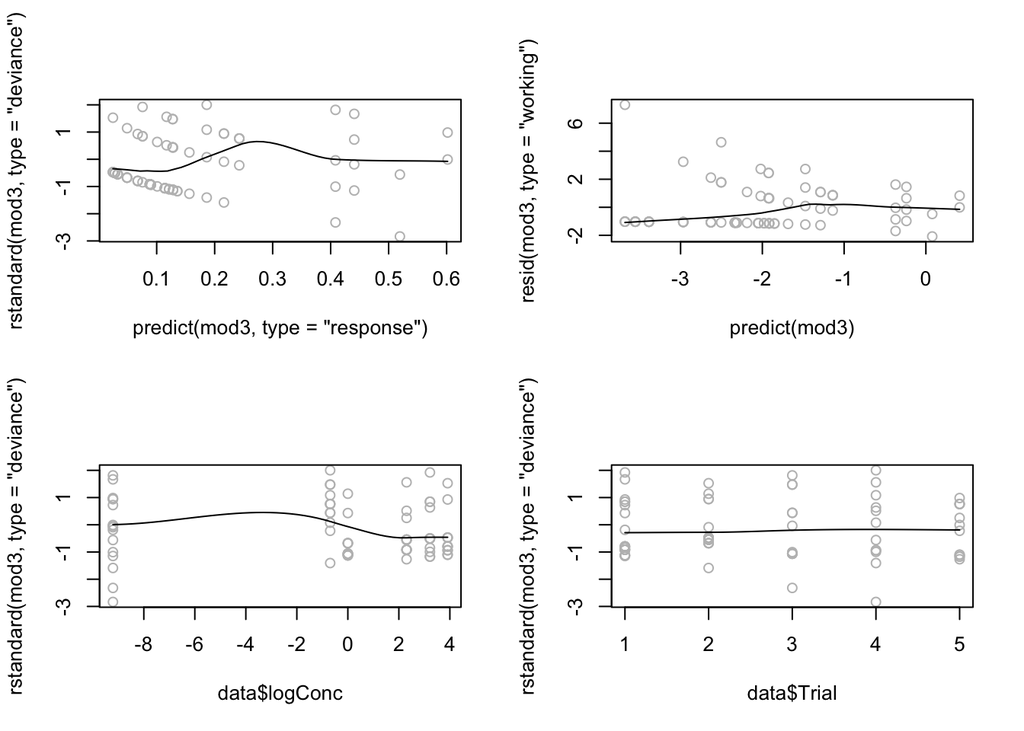

```r
#Residual plots for mod3
par(mfrow=c(2,2))
scatter.smooth(predict(mod3, type='response'), rstandard(mod3, type='deviance'), col='gray')
scatter.smooth(predict(mod3), resid(mod3, type='working'), col='gray')
scatter.smooth(data$logConc, rstandard(mod3, type='deviance'), col='gray')
scatter.smooth(data$Trial, rstandard(mod3, type='deviance'), col='gray')
```

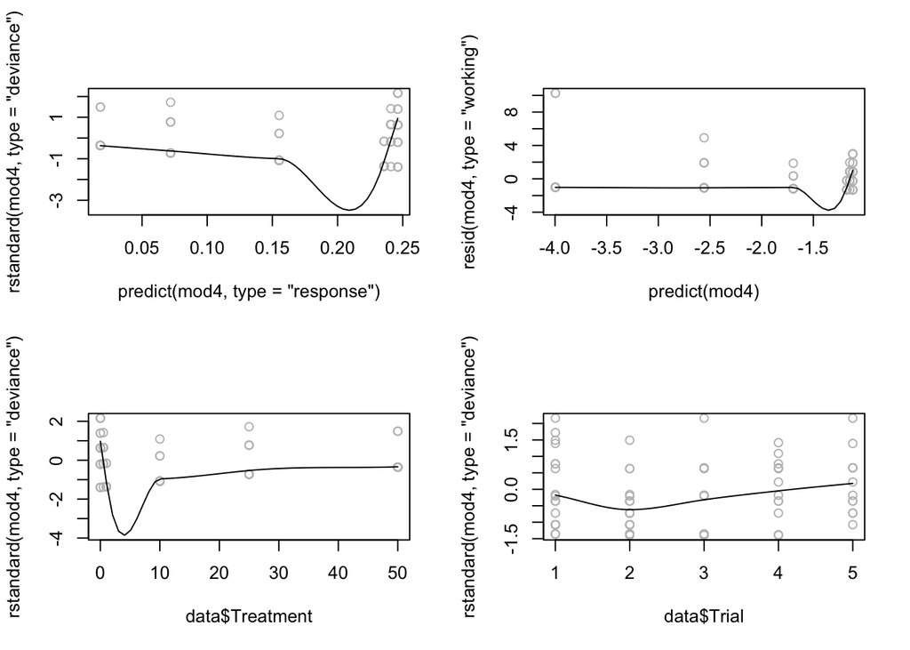

```r
#Residual plots for mod4
scatter.smooth(predict(mod4, type='response'), rstandard(mod4, type='deviance'), col='gray')
scatter.smooth(predict(mod4), resid(mod4, type='working'), col='gray')
scatter.smooth(data$Treatment, rstandard(mod4, type='deviance'), col='gray')
scatter.smooth(data$Trial, rstandard(mod4, type='deviance'), col='gray')
```

The residual plots look cleaner for mod3 than for mod4, and it makes sense to look at the response as a function of log-transformed concentration given the concentration values(0, 0.5, 1, 10, 25, and 50).

Now let’s try to plot the model predictions.

### GLM Prediction Plots

```r
# Model predictions
mod3_eff <- effect("logConc", mod3)
mod3_eff <- as.data.frame(mod3_eff)

# Custom ticks and labels since x-axis is log-transformed
custom_ticks <- c(0.000125, 0.5, 1, 10, 25, 50)
custom_labels <- c("0", "0.5", "1", "10", "25", "50")

# Plot using ggplot2
settle_plot <- ggplot(mod3_eff, aes(x = logConc, y = fit)) +
  geom_line() +
  geom_ribbon(aes(ymin = lower, ymax = upper), alpha = 0.2) +
  labs(x = bquote(Sediment~Concentration~(mg/cm^2)), y = "Settlement Rate (%)") +
  scale_x_continuous(
    breaks = log(custom_ticks),
    labels = custom_labels
  ) +
  scale_y_continuous(
    breaks = seq(0, 1, 0.2),
    limits = c(0, 1),
    labels = function(x) paste0(x*100)
  ) +
  theme_minimal()

#Print model summary
summary(mod3)
```

```
##
## Call:
## glm(formula = settle_prop ~ logConc + Trial, family = quasibinomial,
##     data = data, weights = total_larvae)
##
## Coefficients:
##             Estimate Std. Error t value Pr(>|t|)
## (Intercept)  -1.9166     0.3292  -5.822 1.61e-07 ***
## logConc      -0.1822     0.0314  -5.803 1.74e-07 ***
## Trial2       -1.0509     0.5433  -1.934   0.0571 .
## Trial3       -0.1326     0.4816  -0.275   0.7839
## Trial4        0.3160     0.4896   0.645   0.5207
## Trial5        0.6509     0.4709   1.382   0.1713
## ---
## Signif. codes:  0 '***' 0.001 '**' 0.01 '*' 0.05 '.' 0.1 ' ' 1
##
## (Dispersion parameter for quasibinomial family taken to be 1.148223)
##
##     Null deviance: 138.593  on 75  degrees of freedom
## Residual deviance:  85.679  on 70  degrees of freedom
## AIC: NA
##
## Number of Fisher Scoring iterations: 5
```

### Interpreting Results

There is a significant decrease in larval settlement as sediment concentration increases. Since sediment concentrations were log-transformed in the model, let’s back-transform the model output to quantify the effect of sediment on settlement.

If logit(pi) = beta0 + beta1*log(X), then a k-fold change in X corresponds to a multiplicative change in the odds of k^beta-1. Given this general formula, below are two ways to interpret the results:

1. for every one unit increase in sediment concentration
2. for every ten unit increase in sediment concentration

Let’s start with a one unit increase in concentration…

```r
# Extract 95% confidence intervals for the coefficients and coefficient estimates
conf_intervals <- confint(mod3, level = 0.95)
coefficients <- coef(mod3)

# Back-transform the coefficients and confidence intervals
exp_coefficients <- exp(coefficients) - 0.0001
exp_conf_intervals <- exp(conf_intervals) - 0.0001

# Extract p-values from the model summary
p_values <- round(summary(mod3)$coefficients[, 4], digits = 3)


# Print the estimates
estimates <- cbind(exp_coefficients, exp_conf_intervals, p_values)
print(estimates)
```

```
##             exp_coefficients      2.5 %    97.5 % p_values
## (Intercept)        0.1469987 0.07357175 0.2696884    0.000
## logConc            0.8333142 0.78239521 0.8853476    0.000
## Trial2             0.3495183 0.11259818 0.9769504    0.057
## Trial3             0.8757559 0.33432056 2.2388289    0.784
## Trial4             1.3715651 0.51674164 3.5801576    0.521
## Trial5             1.9171654 0.75892597 4.8712551    0.171
```

```r
# Calculate the % decrease.
dec_exp_coefficients <- round(1 - (exp(coefficients) - 0.0001), digits = 3)
dec_exp_conf_intervals <- round(1 - (exp(conf_intervals) - 0.0001), digits = 3)


# Print the estimates
estimates2 <- cbind(dec_exp_coefficients, dec_exp_conf_intervals, p_values)
print(estimates2)
```

```
##             dec_exp_coefficients 2.5 % 97.5 % p_values
## (Intercept)                0.853 0.926  0.730    0.000
## logConc                    0.167 0.218  0.115    0.000
## Trial2                     0.650 0.887  0.023    0.057
## Trial3                     0.124 0.666 -1.239    0.784
## Trial4                    -0.372 0.483 -2.580    0.521
## Trial5                    -0.917 0.241 -3.871    0.171
```

The estimated odds of a larva settling decrease by 16.7% for every one unit increase in sediment concentration (95% CI 11.5-21.8, GLM p<0.001).

Now, let’s find out what the change is for every ten unit increase in concentration…

```r
# Back-transform the coefficients and confidence intervals
ten_coefficients <- round(exp(10*coefficients) - 0.0001, digits = 3)
ten_conf_intervals <- round(exp(10*conf_intervals) - 0.0001, digits = 3)


# Print the estimates
ten_estimates <- cbind(ten_coefficients, ten_conf_intervals, p_values)
print(ten_estimates)
```

```
##             ten_coefficients 2.5 %      97.5 % p_values
## (Intercept)            0.000 0.000       0.000    0.000
## logConc                0.162 0.086       0.296    0.000
## Trial2                 0.000 0.000       0.793    0.057
## Trial3                 0.266 0.000    3165.213    0.784
## Trial4                23.576 0.001  346053.107    0.521
## Trial5               671.154 0.063 7524851.222    0.171
```

```r
# Calculate the % decrease.
dec_ten_coefficients <- round(1 - (exp(10*coefficients) - 0.0001), digits = 3)
dec_ten_conf_intervals <- round(1 - (exp(10*conf_intervals) - 0.0001), digits = 3)


# Print the estimates
ten_estimates2 <- cbind(dec_ten_coefficients, dec_ten_conf_intervals, p_values)
print(ten_estimates2)
```

```
##             dec_ten_coefficients 2.5 %       97.5 % p_values
## (Intercept)                1.000 1.000        1.000    0.000
## logConc                    0.838 0.914        0.704    0.000
## Trial2                     1.000 1.000        0.207    0.057
## Trial3                     0.734 1.000    -3164.213    0.784
## Trial4                   -22.576 0.999  -346052.107    0.521
## Trial5                  -670.154 0.937 -7524850.222    0.171
```

For every ten unit increase in sediment concentration, the estimated odds of a larva settling decrease by 83.8% (95% CI 70.4-91.4, GLM p<0.001).

# Response: Partially metamorphosed

### GLM Model Validation

```r
# Start with full, binomial model
mod1meta <- glm(meta_prop ~ Treatment + Trial, family = binomial, weights = total_larvae,
            data = data)
summary(mod1meta)
```

```
##
## Call:
## glm(formula = meta_prop ~ Treatment + Trial, family = binomial,
##     data = data, weights = total_larvae)
##
## Coefficients:
##               Estimate Std. Error z value Pr(>|z|)
## (Intercept) -2.815e+00  4.032e-01  -6.981 2.93e-12 ***
## Treatment    3.686e-02  9.028e-03   4.083 4.44e-05 ***
## Trial2       1.053e-15  4.497e-01   0.000  1.00000
## Trial3      -1.281e+00  1.085e+00  -1.181  0.23778
## Trial4      -1.735e+01  1.256e+03  -0.014  0.98898
## Trial5       1.368e+00  4.445e-01   3.078  0.00209 **
## ---
## Signif. codes:  0 '***' 0.001 '**' 0.01 '*' 0.05 '.' 0.1 ' ' 1
##
## (Dispersion parameter for binomial family taken to be 1)
##
##     Null deviance: 137.704  on 75  degrees of freedom
## Residual deviance:  82.421  on 70  degrees of freedom
## AIC: 138.54
##
## Number of Fisher Scoring iterations: 17
```

```r
# Test for Overdispersion
residual_deviance_meta <- deviance(mod1meta)
df_meta <- nrow(model.matrix(mod1meta)) - length(coefficients(mod1meta))
p_value_meta <- 1 - pchisq(residual_deviance_meta, df)

# Print results
print(paste("Residual Deviance:", residual_deviance_meta))
```

```
## [1] "Residual Deviance: 82.4207402141367"
```

```r
print(paste("Degrees of freedom:", df_meta))
```

```
## [1] "Degrees of freedom: 70"
```

```r
print(paste("P-value:", p_value_meta))
```

```
## [1] "P-value: 0.147094444564805"
```

There is no evidence of overdispersion with the binomial, so I will keep the binomial.

```r
mod2meta <- glm(meta_prop ~ Treatment + Trial, family = binomial, weights = total_larvae,
            data = data)
mod3meta <- glm(meta_prop ~ logConc + Trial, family = binomial, weights = total_larvae,
            data = data)
mod4meta <- glm(meta_prop ~ Treatment, family = binomial, weights = total_larvae,
            data = data)
mod5meta <- glm(meta_prop ~ logConc, family = binomial, weights = total_larvae,
            data = data)

# Compare full vs reduced models, with and without log-transformed concentration
anova(mod4meta, mod2meta, test = "Chisq")
```

```
## Analysis of Deviance Table
##
## Model 1: meta_prop ~ Treatment
## Model 2: meta_prop ~ Treatment + Trial
##   Resid. Df Resid. Dev Df Deviance  Pr(>Chi)
## 1        74    116.683
## 2        70     82.421  4   34.262 6.583e-07 ***
## ---
## Signif. codes:  0 '***' 0.001 '**' 0.01 '*' 0.05 '.' 0.1 ' ' 1
```

```r
anova(mod5meta, mod3meta, test = "Chisq")
```

```
## Analysis of Deviance Table
##
## Model 1: meta_prop ~ logConc
## Model 2: meta_prop ~ logConc + Trial
##   Resid. Df Resid. Dev Df Deviance  Pr(>Chi)
## 1        74    106.044
## 2        70     72.916  4   33.129 1.124e-06 ***
## ---
## Signif. codes:  0 '***' 0.001 '**' 0.01 '*' 0.05 '.' 0.1 ' ' 1
```

Based on the Chi sq test, mod2 and mod3 are preferred. Let’s plot the residuals.

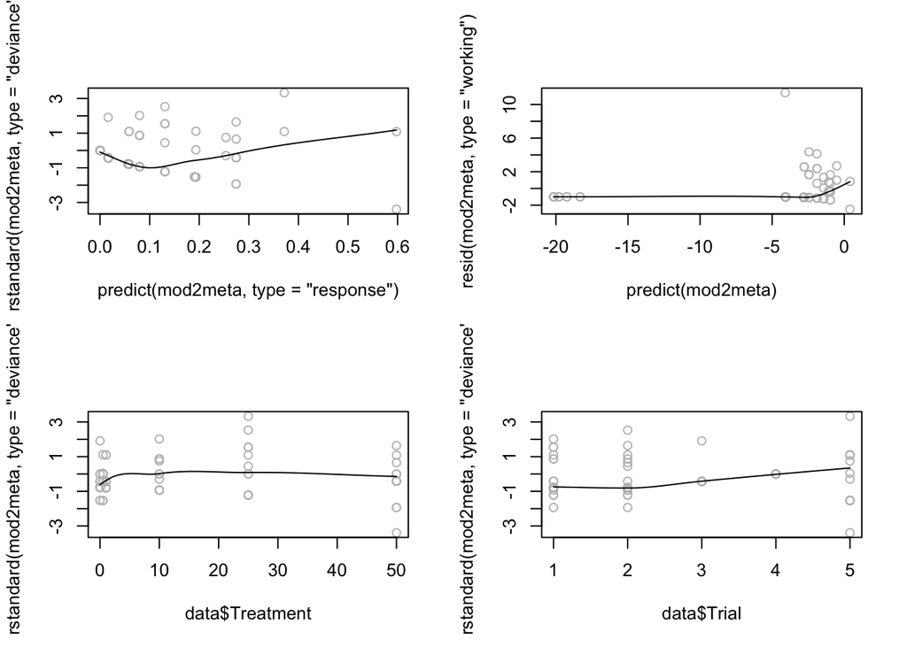

```r
#Residual plots for mod2
par(mfrow=c(2,2))
scatter.smooth(predict(mod2meta, type='response'), rstandard(mod2meta, type='deviance'), col='gray')
scatter.smooth(predict(mod2meta), resid(mod2meta, type='working'), col='gray')
scatter.smooth(data$Treatment, rstandard(mod2meta, type='deviance'), col='gray')
scatter.smooth(data$Trial, rstandard(mod2meta, type='deviance'), col='gray')
```

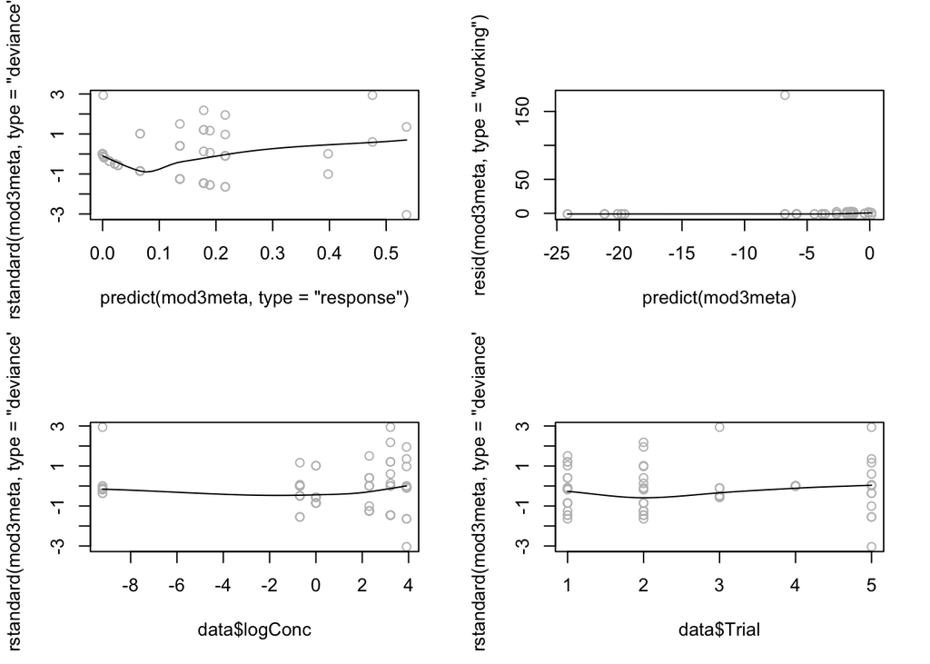

```r
#Residual plots for mod3
scatter.smooth(predict(mod3meta, type='response'), rstandard(mod3meta, type='deviance'), col='gray')
scatter.smooth(predict(mod3meta), resid(mod3meta, type='working'), col='gray')
scatter.smooth(data$logConc, rstandard(mod3meta, type='deviance'), col='gray')
scatter.smooth(data$Trial, rstandard(mod3meta, type='deviance'), col='gray')
```

The residual plots look cleaner for mod3 than for mod2, so let’s look at the response as a function of log-transformed concentration.

### GLM Prediction Plots

```r
# Model predictions
mod3meta_eff <- effect("logConc", mod3meta)
mod3meta_eff <- as.data.frame(mod3meta_eff)

# Custom ticks and labels (since x-axis is log-transformed)
custom_ticks <- c(0.000125, 0.5, 1, 10, 25, 50)
custom_labels <- c("0", "0.5", "1", "10", "25", "50")

# Plot using ggplot2
pm_plot <- ggplot(mod3meta_eff, aes(x = logConc, y = fit)) +
  geom_line() +
  geom_ribbon(aes(ymin = lower, ymax = upper), alpha = 0.2) +
  labs(x = bquote(Sediment~Concentration~(mg/cm^2)), y = "Proportion partially metamorphosed") +
  scale_x_continuous(
    breaks = log(custom_ticks),
    labels = custom_labels
  ) +
  scale_y_continuous(
    breaks = seq(0, 1, 0.2),
    limits = c(0, 1)
  ) +
  theme_minimal()
```

### Interpreting results

The model has wide confidence intervals and the predicted values are consistently different from the actual values. Instead, let’s visualize the raw data for partial metamorphosis.

```r
meta_plot <- ggplot(data, aes(x = logConc, y = meta_prop)) +
  geom_point(position = "jitter") +
  geom_smooth(method = "lm", se = FALSE, color = "black") +
  labs(x = bquote(Sediment~Concentration~(mg/cm^2)), y = "Partial Metamorphosis Rate (%)") +
  scale_x_continuous(
    breaks = log(custom_ticks),
    labels = custom_labels
  ) +
  scale_y_continuous(
    breaks = seq(0, 1, 0.2),
    limits = c(0, 1),
    labels = function(x) paste0(x*100)
  ) +
  theme_minimal()
```

# Response: Swimming

### GLM Model Validation

```r
# Start with full, binomial model
mod1swim <- glm(swim_prop ~ Treatment + Trial, family = binomial, weights = total_larvae,
            data = data)
summary(mod1swim)
```

```
##
## Call:
## glm(formula = swim_prop ~ Treatment + Trial, family = binomial,
##     data = data, weights = total_larvae)
##
## Coefficients:
##              Estimate Std. Error z value Pr(>|z|)
## (Intercept)  0.328994   0.231713   1.420   0.1557
## Treatment    0.002041   0.006508   0.314   0.7538
## Trial2       0.531592   0.299894   1.773   0.0763 .
## Trial3       0.289025   0.355301   0.813   0.4160
## Trial4       0.261001   0.339121   0.770   0.4415
## Trial5      -1.548201   0.367128  -4.217 2.48e-05 ***
## ---
## Signif. codes:  0 '***' 0.001 '**' 0.01 '*' 0.05 '.' 0.1 ' ' 1
##
## (Dispersion parameter for binomial family taken to be 1)
##
##     Null deviance: 194.31  on 75  degrees of freedom
## Residual deviance: 154.63  on 70  degrees of freedom
## AIC: 274.76
##
## Number of Fisher Scoring iterations: 4
```

```r
# Test for Overdispersion
residual_deviance_swim <- deviance(mod1swim)
df_swim <- nrow(model.matrix(mod1swim)) - length(coefficients(mod1swim))
p_value_swim <- 1 - pchisq(residual_deviance_swim, df)

# Print results
print(paste("Residual Deviance:", residual_deviance_swim))
```

```
## [1] "Residual Deviance: 154.631840609345"
```

```r
print(paste("Degrees of freedom:", df_swim))
```

```
## [1] "Degrees of freedom: 70"
```

```r
print(paste("P-value:", p_value_swim))
```

```
## [1] "P-value: 2.49733873580738e-08"
```

There is evidence of overdispersion (p < 0.05) so let’s change this to a quasibinomial distribution.

```r
mod2swim <- glm(swim_prop ~ Treatment + Trial, family = quasibinomial, weights = total_larvae,
            data = data)
mod3swim <- glm(swim_prop ~ logConc + Trial, family = quasibinomial, weights = total_larvae,
            data = data)
mod4swim <- glm(swim_prop ~ Treatment, family = quasibinomial, weights = total_larvae,
            data = data)
mod5swim <- glm(swim_prop ~ logConc, family = quasibinomial, weights = total_larvae,
            data = data)

# Compare full vs reduced models, with or without log transformed concentration
anova(mod4swim, mod2swim, test = "Chisq")
```

```
## Analysis of Deviance Table
##
## Model 1: swim_prop ~ Treatment
## Model 2: swim_prop ~ Treatment + Trial
##   Resid. Df Resid. Dev Df Deviance  Pr(>Chi)
## 1        74     194.28
## 2        70     154.63  4   39.645 0.0003008 ***
## ---
## Signif. codes:  0 '***' 0.001 '**' 0.01 '*' 0.05 '.' 0.1 ' ' 1
```

```r
anova(mod5swim, mod3swim, test = "Chisq")
```

```
## Analysis of Deviance Table
##
## Model 1: swim_prop ~ logConc
## Model 2: swim_prop ~ logConc + Trial
##   Resid. Df Resid. Dev Df Deviance Pr(>Chi)
## 1        74     189.53
## 2        70     148.00  4   41.523  0.00013 ***
## ---
## Signif. codes:  0 '***' 0.001 '**' 0.01 '*' 0.05 '.' 0.1 ' ' 1
```

Based on the Chi sq test, mod2 and mod3 are preferred. Let’s plot the residuals.

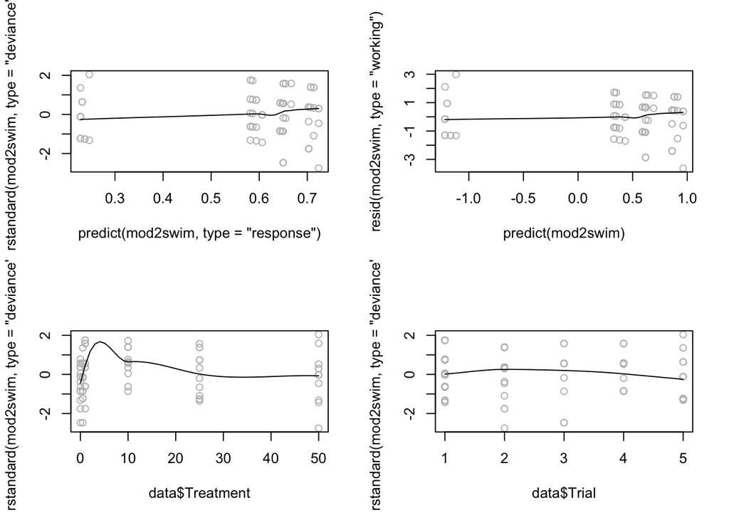

```r
#Residual plots for mod2
par(mfrow=c(2,2))
scatter.smooth(predict(mod2swim, type='response'), rstandard(mod2swim, type='deviance'), col='gray')
scatter.smooth(predict(mod2swim), resid(mod2swim, type='working'), col='gray')
scatter.smooth(data$Treatment, rstandard(mod2swim, type='deviance'), col='gray')
scatter.smooth(data$Trial, rstandard(mod2swim, type='deviance'), col='gray')
```

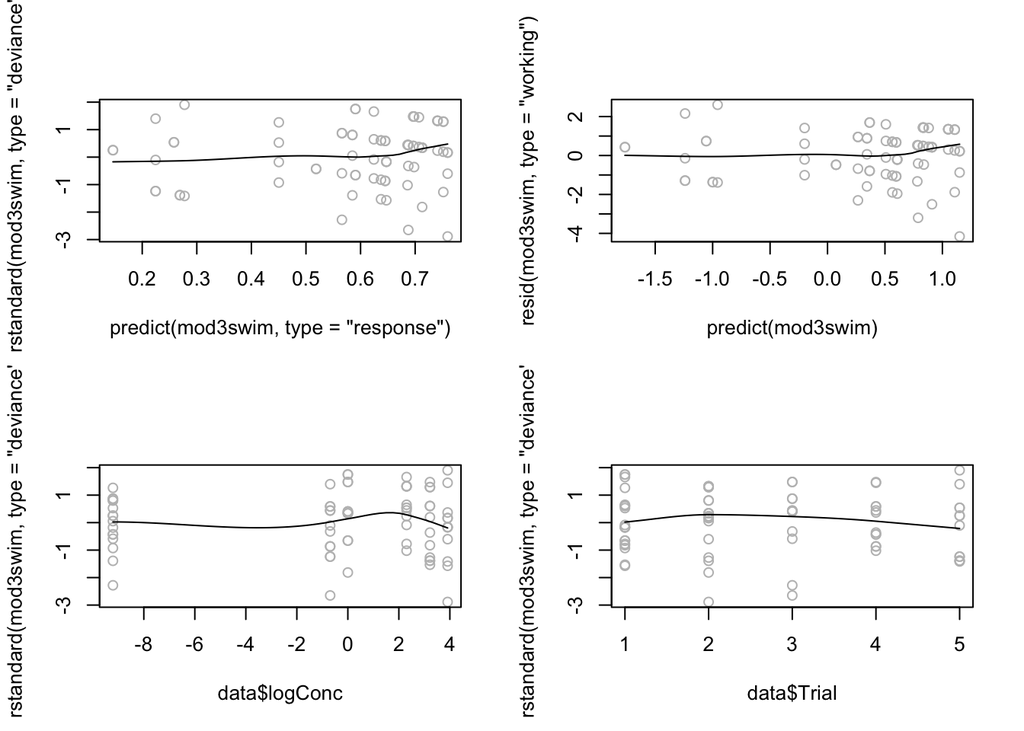

```r
#Residual plots for mod3
scatter.smooth(predict(mod3swim, type='response'), rstandard(mod3swim, type='deviance'), col='gray')
scatter.smooth(predict(mod3swim), resid(mod3swim, type='working'), col='gray')
scatter.smooth(data$logConc, rstandard(mod3swim, type='deviance'), col='gray')
scatter.smooth(data$Trial, rstandard(mod3swim, type='deviance'), col='gray')
```

The residual plots look cleaner for mod3 than for mod2, so let’s look at the response as a function of log-transformed concentration.

### GLM Prediction Plots

```r
# Model predictions
mod3swim_eff <- effect("logConc", mod3swim)
mod3swim_eff <- as.data.frame(mod3swim_eff)

# Custom ticks and labels (since x-axis is log-transformed)
custom_ticks <- c(0.000125, 0.5, 1, 10, 25, 50)
custom_labels <- c("0", "0.5", "1", "10", "25", "50")

# Plot using ggplot2
swim_plot <- ggplot(mod3swim_eff, aes(x = logConc, y = fit)) +
  geom_line() +
  geom_ribbon(aes(ymin = lower, ymax = upper), alpha = 0.2) +
  labs(x = bquote(Sediment~Concentration~(mg/cm^2)), y = "Rate of Larval Swimming (%)") +
  scale_x_continuous(
    breaks = log(custom_ticks),
    labels = custom_labels
  ) +
  scale_y_continuous(
    breaks = seq(0, 1, 0.2),
    limits = c(0, 1),
    labels = function(x) paste0(x*100)
  ) +
  theme_minimal()

#Model Summary
summary(mod3swim)
```

```
##
## Call:
## glm(formula = swim_prop ~ logConc + Trial, family = quasibinomial,
##     data = data, weights = total_larvae)
##
## Coefficients:
##             Estimate Std. Error t value Pr(>|t|)
## (Intercept)  0.36656    0.27656   1.325  0.18933
## logConc      0.06146    0.03195   1.924  0.05845 .
## Trial2       0.54291    0.40785   1.331  0.18745
## Trial3       0.46457    0.47296   0.982  0.32935
## Trial4       0.27379    0.46001   0.595  0.55364
## Trial5      -1.56381    0.49720  -3.145  0.00244 **
## ---
## Signif. codes:  0 '***' 0.001 '**' 0.01 '*' 0.05 '.' 0.1 ' ' 1
##
## (Dispersion parameter for quasibinomial family taken to be 1.809845)
##
##     Null deviance: 194.31  on 75  degrees of freedom
## Residual deviance: 148.00  on 70  degrees of freedom
## AIC: NA
##
## Number of Fisher Scoring iterations: 4
```

### Interpreting results

The estimated odds of a larva swimming was unaffected by sediment concentration (GLM p > 0.05).

# Response: Mortality

### GLM Model Validation

```r
# Start with full, binomial model
mod1dead <- glm(dead_prop ~ Treatment + Trial, family = binomial, weights = total_larvae,
            data = data)
summary(mod1dead)
```

```
##
## Call:
## glm(formula = dead_prop ~ Treatment + Trial, family = binomial,
##     data = data, weights = total_larvae)
##
## Coefficients:
##               Estimate Std. Error z value Pr(>|z|)
## (Intercept) -1.9036897  0.3334681  -5.709 1.14e-08 ***
## Treatment    0.0001586  0.0087557   0.018    0.986
## Trial2      -0.2962661  0.4466777  -0.663    0.507
## Trial3      -0.1207713  0.5211665  -0.232    0.817
## Trial4       0.1668126  0.4687875   0.356    0.722
## Trial5       0.6162160  0.4327201   1.424    0.154
## ---
## Signif. codes:  0 '***' 0.001 '**' 0.01 '*' 0.05 '.' 0.1 ' ' 1
##
## (Dispersion parameter for binomial family taken to be 1)
##
##     Null deviance: 115.99  on 75  degrees of freedom
## Residual deviance: 111.57  on 70  degrees of freedom
## AIC: 187.66
##
## Number of Fisher Scoring iterations: 4
```

```r
# Test for Overdispersion
residual_deviance_dead <- deviance(mod1dead)
df_dead <- nrow(model.matrix(mod1dead)) - length(coefficients(mod1dead))
p_value_dead <- 1 - pchisq(residual_deviance_dead, df)

# Print results
print(paste("Residual Deviance:", residual_deviance_dead))
```

```
## [1] "Residual Deviance: 111.567402429629"
```

```r
print(paste("Degrees of freedom:", df_dead))
```

```
## [1] "Degrees of freedom: 70"
```

```r
print(paste("P-value:", p_value_dead))
```

```
## [1] "P-value: 0.00116857438711582"
```

There is evidence of overdispersion (p < 0.05) so let’s change this to a quasibinomial distribution.

```r
mod2dead <- glm(dead_prop ~ Treatment + Trial, family = quasibinomial, weights = total_larvae,
            data = data)
mod3dead <- glm(dead_prop ~ logConc + Trial, family = quasibinomial, weights = total_larvae,
            data = data)
mod4dead <- glm(dead_prop ~ Treatment, family = quasibinomial, weights = total_larvae,
            data = data)
mod5dead <- glm(dead_prop ~ logConc, family = quasibinomial, weights = total_larvae,
            data = data)

# Compare full vs reduced models, with and without log-transformed concentration
anova(mod4dead, mod2dead, test = "Chisq")
```

```
## Analysis of Deviance Table
##
## Model 1: dead_prop ~ Treatment
## Model 2: dead_prop ~ Treatment + Trial
##   Resid. Df Resid. Dev Df Deviance Pr(>Chi)
## 1        74     115.98
## 2        70     111.57  4    4.416   0.6241
```

```r
anova(mod5dead, mod3dead, test = "Chisq")
```

```
## Analysis of Deviance Table
##
## Model 1: dead_prop ~ logConc
## Model 2: dead_prop ~ logConc + Trial
##   Resid. Df Resid. Dev Df Deviance Pr(>Chi)
## 1        74     115.98
## 2        70     111.53  4   4.4461   0.6201
```

Based on the Chi sq test, mod4 and mod5 are sufficient, but since this deviates from the models for the previous larval responses, let’s take a look at the residuals for mod2, mod3, mod4 and mod5.

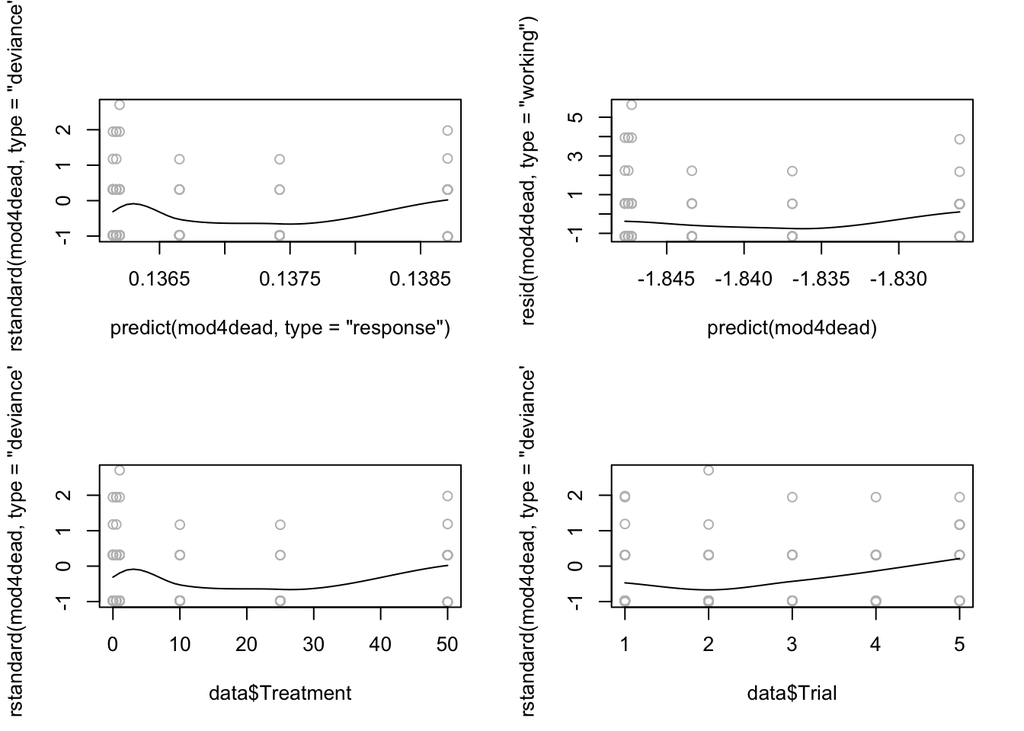

```r
#Residual plots for mod4
par(mfrow=c(2,2))
scatter.smooth(predict(mod4dead, type='response'), rstandard(mod4dead, type='deviance'), col='gray')
scatter.smooth(predict(mod4dead), resid(mod4dead, type='working'), col='gray')
scatter.smooth(data$Treatment, rstandard(mod4dead, type='deviance'), col='gray')
scatter.smooth(data$Trial, rstandard(mod4dead, type='deviance'), col='gray')
```

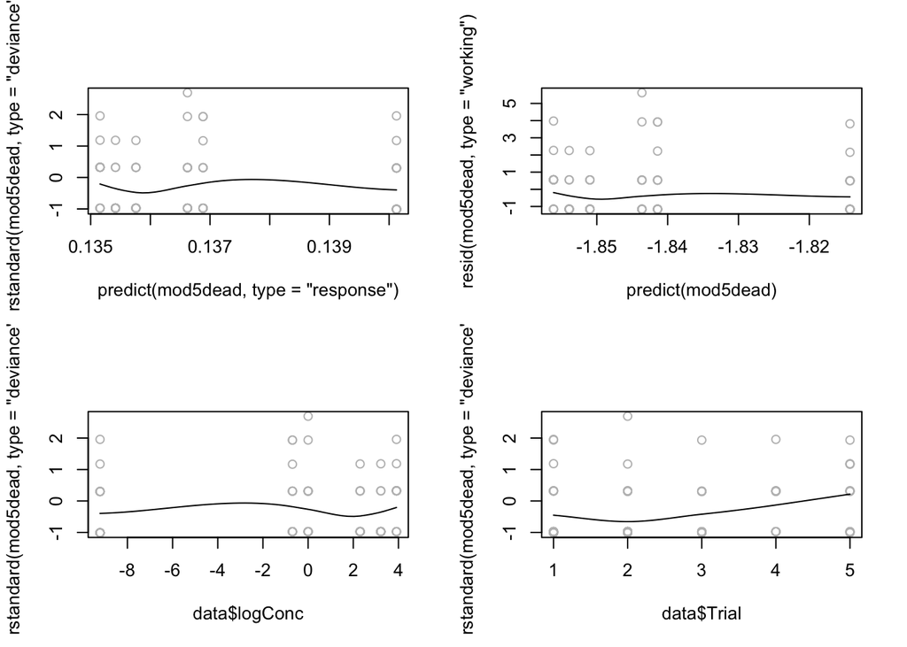

```r
#Residual plots for mod5
scatter.smooth(predict(mod5dead, type='response'), rstandard(mod5dead, type='deviance'), col='gray')
scatter.smooth(predict(mod5dead), resid(mod5dead, type='working'), col='gray')
scatter.smooth(data$logConc, rstandard(mod5dead, type='deviance'), col='gray')
scatter.smooth(data$Trial, rstandard(mod5dead, type='deviance'), col='gray')
```

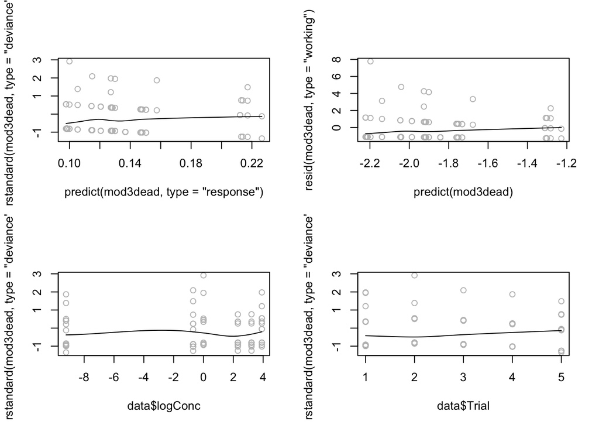

```r
#Residual plots for mod3
scatter.smooth(predict(mod3dead, type='response'), rstandard(mod3dead, type='deviance'), col='gray')
scatter.smooth(predict(mod3dead), resid(mod3dead, type='working'), col='gray')
scatter.smooth(data$logConc, rstandard(mod3dead, type='deviance'), col='gray')
scatter.smooth(data$Trial, rstandard(mod3dead, type='deviance'), col='gray')
```

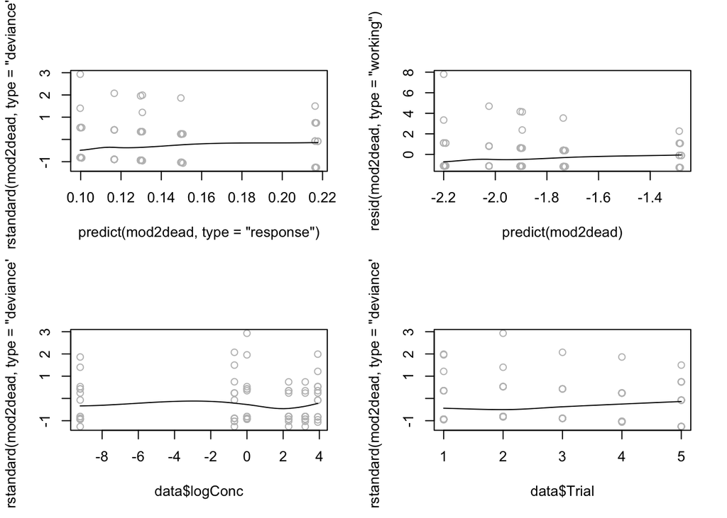

```r
#Residual plots for mod2
scatter.smooth(predict(mod2dead, type='response'), rstandard(mod2dead, type='deviance'), col='gray')
scatter.smooth(predict(mod2dead), resid(mod2dead, type='working'), col='gray')
scatter.smooth(data$logConc, rstandard(mod2dead, type='deviance'), col='gray')
scatter.smooth(data$Trial, rstandard(mod2dead, type='deviance'), col='gray')
```

The residual plots for mod3 look better, and to keep models consistent across response types, let’s look at the response as a function of log-transformed concentration.

```r
# Model predictions
mod3dead_eff <- effect("logConc", mod3dead)
mod3dead_eff <- as.data.frame(mod3dead_eff)

# Custom ticks and labels (since x-axis is log-transformed)
custom_ticks <- c(0.000125, 0.5, 1, 10, 25, 50)
custom_labels <- c("0", "0.5", "1", "10", "25", "50")

# Plot using ggplot2
dead_plot <- ggplot(mod3dead_eff, aes(x = logConc, y = fit)) +
  geom_line() +
  geom_ribbon(aes(ymin = lower, ymax = upper), alpha = 0.2) +
  labs(x = bquote(Sediment~Concentration~(mg/cm^2)), y = "Larval Mortality Rate (%)") +
  scale_x_continuous(
    breaks = log(custom_ticks),
    labels = custom_labels
  ) +
  scale_y_continuous(
    breaks = seq(0, 1, 0.2),
    limits = c(0, 1),
    labels = function(x) paste0(x*100)
  ) +
  theme_minimal()

# Model summary
summary(mod3dead)
```

```
##
## Call:
## glm(formula = dead_prop ~ logConc + Trial, family = quasibinomial,
##     data = data, weights = total_larvae)
##
## Coefficients:
##              Estimate Std. Error t value Pr(>|t|)
## (Intercept) -1.901024   0.386049  -4.924 5.44e-06 ***
## logConc     -0.006366   0.042181  -0.151    0.880
## Trial2      -0.296295   0.579920  -0.511    0.611
## Trial3      -0.144646   0.664257  -0.218    0.828
## Trial4       0.164912   0.607820   0.271    0.787
## Trial5       0.614369   0.560915   1.095    0.277
## ---
## Signif. codes:  0 '***' 0.001 '**' 0.01 '*' 0.05 '.' 0.1 ' ' 1
##
## (Dispersion parameter for quasibinomial family taken to be 1.68542)
##
##     Null deviance: 115.99  on 75  degrees of freedom
## Residual deviance: 111.53  on 70  degrees of freedom
## AIC: NA
##
## Number of Fisher Scoring iterations: 4
```

### Interpreting results

The estimated odds of a larva dying was unaffected by sediment concentration (GLM p > 0.05).